# nimbleFunction programming

NIMBLE 2021 Virtual Workshop

NIMBLE Development Team

May 2021

# Agenda

1. Review of nimbleFunctions with setupCode
2. nimbleFunctions for new (i.e., user-defined) samplers
   1. Design of NIMBLE’s MCMC system
   2. Setting up a new sampler: A simple Metropolis-Hastings example
   3. Worked example: sampler that jointly updates intercepts and random effects in the E. cervi example.
3. modelValues for storing values from a model
4. nimbleFunctions for post-processing
   1. Worked example: posterior predictive checks
   2. Worked example: sampling from marginalized nodes
5. Calling out to R and C++ from nimbleFunctions

# Load Deer E. cervi example

```r
source(file.path("..", "examples", "DeerEcervi", "load_DeerEcervi.R"), chdir = TRUE)
set.seed(123)
DEmodel <- nimbleModel(DEcode,
                        constants = DEconstants,
                        data = list(Ecervi_01 = DeerEcervi$Ecervi_01),
                        inits = DEinits())
```

```
## defining model...
```

```
## building model...
```

```
## setting data and initial values...
```

```
## running calculate on model (any error reports that follow may simply reflect missing values in model variables) ...
## checking model sizes and dimensions...
## model building finished.
```

# Design of `nimble`’s MCMC system

1. MCMC configuration object: Contains a list of sampler assignments, not actual samplers.
2. MCMC object: Contains a list of sampler objects.

To write new samplers, we need to understand:

- Two-stage evaluation of nimbleFunctions with setup code.
- Setup (configuration) rules for using a new MCMC sampler
- Run-time rules for management of model calculations and saved states.
- More about nimbleFunction programming.

# Example of MCMC configuration object

Look at MCMC configuration object for just a few nodes

```r
mcmcConf <- configureMCMC(DEmodel, nodes = 'farm_effect[1:3]')
```

```
## ===== Monitors =====
## thin = 1: sex_int, length_coef, farm_sd
## ===== Samplers =====
## RW sampler (3)
##   - farm_effect[]  (3 elements)
```

```r
class(mcmcConf)
```

```
## [1] "MCMCconf"
## attr(,"package")
## [1] "nimble"
```

```r
ls(mcmcConf)
```

```
##  [1] "addConjugateSampler"   "addMonitors"
##  [3] "addMonitors2"          "addSampler"
##  [5] "addSamplerOne"         "controlDefaults"
##  [7] "enableWAIC"            "findSamplersOnNodes"
##  [9] "getSamplers"           "initialize"
## [11] "isMvSamplesReady"      "model"
## [13] "monitors"              "monitors2"
## [15] "mvSamples1Conf"        "mvSamples2Conf"
## [17] "printMonitors"         "printSamplers"
## [19] "printSamplersByType"   "removeSamplers"
## [21] "samplerConfs"          "samplerExecutionOrder"
## [23] "show"                  "thin"
## [25] "thin2"
```

```r
fe1_sampler <- mcmcConf$getSamplers("farm_effect[1]")[[1]]
class(fe1_sampler)
```

```
## [1] "samplerConf"
## attr(,"package")
## [1] "nimble"
```

```r
ls(fe1_sampler)
```

```
## [1] "control"         "initialize"      "name"            "samplerFunction"
## [5] "target"          "targetAsScalar"
```

```r
fe1_sampler$target
```

```
## [1] "farm_effect[1]"
```

```r
fe1_sampler$control
```

```
## list()
```

# What happens from an MCMC configuration object?

Eventually, an MCMC sampler object is created by a call like this (for adaptive random-walk MH):

```r
sampler_RW(model, mvSaved, target, control)
```

- This is stage one of two-stage evaluation. It instantiates an object of a `sampler_RW` class.
- `model` is the model.
- `mvSaved` is a `modelValues` object for keeping a set of saved model states (more later).
- `target` is a vector of target node names.
- `control` is a list of whatever sampler-specific configuration settings are needed.

# More about nimbleFunctions

- Without setup code, a `nimbleFunction` becomes an R function (uncompiled) and a C++ function (compiled).
- With setup code, a `nimbleFunction` becomes an R reference class definition (uncompiled) and a C++ class definition (compiled).
  - `nimbleFunction` returns a generator (aka constructor, aka initializer) of new class objects.

### nimbleFunction class definitions (i.e., with setup code)

- `setup` is always executed in R.
  - Typically one-time, high-level processing such as querying model structure.
- `run` and other methods can be run uncompiled (in R) or compiled (via C++).
  - Typically repeated “actual algorithm” calculations such as MCMC sampler updates.
  - Can operate models.
- Any objects (e.g., `calcNodes` and `model`) in `setup` can be used in `run`.
  - Internally, these are automatically set up as class member data.
  - You do not need to explicitly declare class member data.
  - Nodes used in model operations are “baked in” (aka partially evaluated) during compilation.
    - Node vectors must be created in setup code and used in run code.
    - They can’t be dynamically modified in run code.

# A basic Random-Walk Metropolis-Hastings sampler

```r
ourMH <- nimbleFunction(
  name = 'ourMH',                              # Convenient for class name of R reference class and generated C++ class
  contains = sampler_BASE,                     # There is a simple class inheritance system.
  setup = function(model, mvSaved, target, control) {                 # REQUIRED setup arguments
    scale <- if(!is.null(control$scale)) control$scale else 1         # Typical extraction of control choices
    calcNodes <- model$getDependencies(target)                        # Typical query of model structure
  },                                                                  # setup can't return anything
  run = function() {
    currentValue <- model[[target]]                                   # extract current value
    currentLogProb <- model$getLogProb(calcNodes)                     # get log "denominator" from cached values
    proposalValue <- rnorm(1, mean = currentValue, sd = scale)        # generate proposal value
    model[[target]] <<- proposalValue                                 # put proposal value in model
    proposalLogProb <- model$calculate(calcNodes)                     # calculate log "numerator"
    logAcceptanceRatio <- proposalLogProb - currentLogProb            # log acceptance ratio
    # Alternative:
    # logAcceptanceRatio <- model$calculateDiff(calcNodes)
    accept <- decide(logAcceptanceRatio)                                          # utility function to generate accept/reject decision
    if(accept)                                                        # accept: synchronize model -> mvSaved
      copy(from = model, to = mvSaved, row = 1, nodes = calcNodes, logProb = TRUE)
    else                                                              # reject: synchronize mvSaved -> model
      copy(from = mvSaved, to = model, row = 1, nodes = calcNodes, logProb = TRUE)
  },
  methods = list(                              # required method for sampler_BASE base class
    reset = function() {}
  )
)
```

# Rules for each sampler

### setup function

- The four arguments, named exactly as shown, are required. This allows `buildMCMC` to create any sampler correctly.

### run function

- The `mvSaved` (“modelValues saved”) has a saved copy of all model variables and log probabilities
- Upon entry, `run()` can assume:
  - the model is fully calculated (so `getLogProb` and `calculateDiff` make sense).
  - `mvSaved` and the model are synchronized (have the same values).
- Upon exit, `run()` must ensure those conditions are met.
  - That way the next sampler can operator correctly.
- Between entry and exit, `run()` can manipulate the model in any way necessary.

### reset function

- To match the `sampler_BASE` definition, all samplers must have a `reset()` function.

# Stepping through uncompiled execution

Version with `browser()`s

```r
ourMH_debug <- nimbleFunction(
  name = 'ourMH_debug',
  contains = sampler_BASE,
  setup = function(model, mvSaved, target, control) {
    browser()
    scale <- if(!is.null(control$scale)) control$scale else 1
    calcNodes <- model$getDependencies(target)
  },
  run = function() {
    browser()
    currentValue <- model[[target]]
    currentLogProb <- model$getLogProb(calcNodes)
    proposalValue <- rnorm(1, mean = currentValue, sd = scale)
    model[[target]] <<- proposalValue
    proposalLogProb <- model$calculate(calcNodes)
    logAcceptanceRatio <- currentLogProb - proposalLogProb
    accept <- decide(logMHR)
    if(accept)
      copy(from = model, to = mvSaved, row = 1, nodes = calcNodes, logProb = TRUE)
    else
      copy(from = mvSaved, to = model, row = 1, nodes = calcNodes, logProb = TRUE)
  },
  methods = list(
    reset = function() {}
  )
)
```

# Stepping through uncompiled execution

```r
mcmcConf <- configureMCMC(DEmodel, nodes = NULL) ## Make an empty configuration
```

```
## ===== Monitors =====
## thin = 1: sex_int, length_coef, farm_sd
## ===== Samplers =====
```

```r
mcmcConf$addSampler(type = "ourMH_debug", target = 'farm_effect[1]')
```

```r
# run this on your own to step through in debug (browser) mode.
mcmc <- buildMCMC(mcmcConf)
mcmc$run(5)
```

# Let’s modify the basic RW sampler

A user wrote to nimble-users recently asking how to do MCMC sampling on subsets of a multivariate node, e.g., for missing data applications.

Unfortunately, `nimble` is not set up to do this. The user took our basic RW sampler and modified it for his need.

Let’s suppose we have this basic model with a node, say `y[1:3]` and `y[2]` is missing.

`nimble` easily handles nodes that are missing (assigning an MCMC sampler to them) but not multivariate nodes that are a mix of missing and non-missing. But we can work around that.

```r
code <- nimbleCode({
     y[1:n] ~ dmnorm(mu[1:n], cov = Sigma[1:n, 1:n])
})
n <- 3
mu <- rep(0, n)
Sigma <- matrix(c(1, .9, -.7, .9, 1, -.6, -.7, -.6, 1), 3, 3)
Sigma
```

```
##      [,1] [,2] [,3]
## [1,]  1.0  0.9 -0.7
## [2,]  0.9  1.0 -0.6
## [3,] -0.7 -0.6  1.0
```

```r
y <- c(0.2, NA, -0.5)
yFull <- y
yFull[2] <- 0
model <- nimbleModel(code, inits = list(y = yFull),
  constants = list(n = n, mu = mu, Sigma = Sigma))
```

```
## defining model...
```

```
## Adding mu, Sigma as data for building model.
```

```
## building model...
```

```
## setting data and initial values...
```

```
## running calculate on model (any error reports that follow may simply reflect missing values in model variables) ...
## checking model sizes and dimensions...
## model building finished.
```

```r
conf <- configureMCMC(model, nodes = NULL)
```

```
## ===== Monitors =====
## thin = 1: y
## ===== Samplers =====
```

```r
# conf$addSampler(target = '???', type = 'conditional_RW', control = list(???))
```

# Let’s modify the basic RW sampler - brainstorming

Let’s open up [`MCMC_samplers.R`](https://github.com/nimble-dev/nimble/blob/devel/packages/nimble/R/MCMC_samplers.R) (and search for `sampler_RW`), so we can have the basic sampler in front of us.

Now let’s consider what we need to do to sample the missing element of `y`.

- What information do we need from the user to set up the sampler?
- What do we need to do in the run code to sample `y[2]`?
  - Note: when we call `calculate`, we need to calculate the multivariate density of `y[1:3]`

# A sampler for an element of a multivariate node

Let’s see the sampler the user came up with.

The key pieces are:

```
#### from setup code:

        ## set incorrect defaults so that it throws an error if not explicitly set
        index <- extractControlElement(control, 'index', 1:2)

        ## checks on index
        if(length(index) != 1) stop('length of index must be 1')
        if(index < 1 | index > d) stop('index must be within length of target')

#### from run code:

        currentValue <- model[[target]]   # recall this is a vector, not a scalar
        propValue <- model[[target]]
        propLogScale <- 0
        if(logScale) {
            propLogScale <- rnorm(1, mean = 0, sd = scale)
            propValue[index] <- currentValue[index] * exp(propLogScale)
        } else {
            propValue[index] <- rnorm(1, mean = currentValue[index],  sd = scale)
        }
        model[[target]] <<- propValue
```

# Using the new sampler

Using the new sampler in `nimble` is easy.

```r
source('conditional_RW.R')
index <- which(is.na(y))
conf$addSampler(target = 'y[1:3]', type = 'conditional_RW', control = list(index = index))
mcmc <- buildMCMC(conf)

cModel <- compileNimble(model)
```

```
## compiling... this may take a minute. Use 'showCompilerOutput = TRUE' to see C++ compilation details.
```

```
## compilation finished.
```

```r
cmcmc <- compileNimble(mcmc, project = model)
```

```
## compiling... this may take a minute. Use 'showCompilerOutput = TRUE' to see C++ compilation details.
## compilation finished.
```

```r
samples <- runMCMC(cmcmc, niter = 1000)
```

```
## running chain 1...
```

```
## |-------------|-------------|-------------|-------------|
## |-------------------------------------------------------|
```

```r
head(samples)
```

```
##      y[1]       y[2] y[3]
## [1,]  0.2 -0.6250393 -0.5
## [2,]  0.2 -0.7704328 -0.5
## [3,]  0.2 -0.6170597 -0.5
## [4,]  0.2 -0.6170597 -0.5
## [5,]  0.2 -0.9371161 -0.5
## [6,]  0.2 -0.9371161 -0.5
```

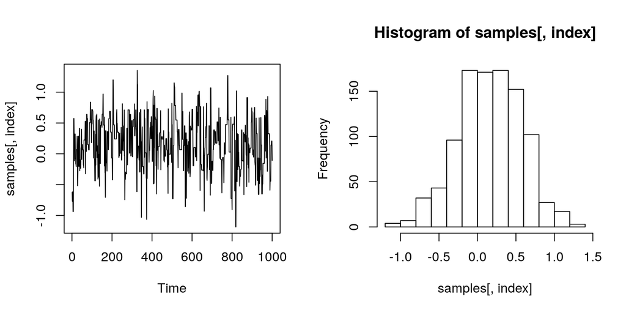

```r
par(mfrow = c(1,2))
ts.plot(samples[ , index] )
hist(samples[ , index])
```

# Let’s make an interesting sampler (1)

Let’s work on a more involved case where we can’t make such simple modifications to an existing sampler.

We’ll put the pieces together for the E. cervi example as follows:

- Use the original parameterization.
- Write a sampler that proposes to add $\delta \sim N(0, \mbox{scale})$ to the two sex-specific intercepts and to subtract the same $\delta$ from every `farm_effect[i]` ($i = 1 \ldots 24$).
- This is a scalar sampler in rotated coordinates.
- The coordinate transformation is linear, so there is no determinant of a Jacobian matrix to incorporate. In general one needs to be careful to use distribution theory correctly if non-linear coordinate transformations are involved. We are covering the software, not the math.
- We want proposal scale to be adaptive (self-tuning as the MCMC proceeds). We will just copy from NIMBLE’s `sampler_RW` to implement that.

# Let’s make an interesting sampler (2)

```r
ourSampler <- nimbleFunction(
  name = 'ourSampler',
  contains = sampler_BASE,
  setup = function(model, mvSaved, target, control) {
    ## control list extraction
    offsetNodes <- control$offsetNodes
    if(is.null(offsetNodes)) stop("Must provide offsetNodes in control list")
    adaptive            <- if(!is.null(control$adaptive))            control$adaptive            else TRUE
    adaptInterval       <- if(!is.null(control$adaptInterval))       control$adaptInterval       else 20 #
    adaptFactorExponent <- if(!is.null(control$adaptFactorExponent)) control$adaptFactorExponent else 0.8
    scale               <- if(!is.null(control$scale))               control$scale               else 1
    ## calculation nodes
    calcNodes <- model$getDependencies(c(target, offsetNodes))
    ## variables for adaptation
    scaleOriginal <- scale
    timesRan      <- 0
    timesAccepted <- 0
    timesAdapted  <- 0
    optimalAR     <- 0.44
    gamma1        <- 0
  },
  run = function() {
    currentTargetValues <- values(model, target)
    currentOffsetNodeValues <- values(model, offsetNodes)
    proposalShift <- rnorm(1, mean = 0, sd = scale)
    proposalTargetValues <- currentTargetValues + proposalShift
    proposalOffsetNodeValues <- currentOffsetNodeValues - proposalShift
    values(model, target) <<- proposalTargetValues
    values(model, offsetNodes) <<- proposalOffsetNodeValues
    logMetropolisHastingsRatio <- calculateDiff(model, calcNodes)
    accept <- decide(logMetropolisHastingsRatio)
    if(accept) nimCopy(from = model, to = mvSaved, row = 1, nodes = calcNodes, logProb = TRUE)
    else     nimCopy(from = mvSaved, to = model, row = 1, nodes = calcNodes, logProb = TRUE)
    if(adaptive)     adaptiveProcedure(accept)
  },
  methods = list(
    adaptiveProcedure = function(accepted = logical()) {
      timesRan <<- timesRan + 1
      if(accepted)     timesAccepted <<- timesAccepted + 1
      if(timesRan %% adaptInterval == 0) {
        acceptanceRate <- timesAccepted / timesRan
        timesAdapted <<- timesAdapted + 1
        gamma1 <<- 1/((timesAdapted + 3)^adaptFactorExponent)
        gamma2 <- 10 * gamma1
        adaptFactor <- exp(gamma2 * (acceptanceRate - optimalAR))
        scale <<- scale * adaptFactor
        timesRan <<- 0
        timesAccepted <<- 0
      }
    },
    reset = function() {
      scale <<- scaleOriginal
      timesRan      <<- 0
      timesAccepted <<- 0
      timesAdapted  <<- 0
      gamma1 <<- 0
    }
  )
)
```

# Let’s make an interesting sampler (3)

Configure and build the MCMC.

```r
mcmcConf <- configureMCMC(DEmodel)
```

```
## ===== Monitors =====
## thin = 1: sex_int, length_coef, farm_sd
## ===== Samplers =====
## RW sampler (29)
##   - sex_int[]  (2 elements)
##   - length_coef[]  (2 elements)
##   - farm_sd
##   - farm_effect[]  (24 elements)
```

```r
mcmcConf$addSampler(target = c('sex_int'),
                    type = ourSampler,
                    control = list(offsetNodes = 'farm_effect'))
mcmc <- buildMCMC(mcmcConf)
```

# Accessing more information from a sampler

One might be interested in accessing compiled internals. Here is code from an on-the-fly example.

```r
## Make compiled model
cDEmodel <- compileNimble(DEmodel)
```

```
## compiling... this may take a minute. Use 'showCompilerOutput = TRUE' to see C++ compilation details.
```

```
## compilation finished.
```

```r
## Set internal option to access compiled samplers inside of compiled mcmc below
nimbleOptions(buildInterfacesForCompiledNestedNimbleFunctions = TRUE)
## Compile the MCMC
cmcmc <- compileNimble(mcmc)
```

```
## compiling... this may take a minute. Use 'showCompilerOutput = TRUE' to see C++ compilation details.
## compilation finished.
```

```r
## See that the run function is an interface to compiled code via .Call
cmcmc$run
```

```
## Class method definition for method run()
## function (niter, reset = TRUE, resetMV = FALSE, time = FALSE,
##     progressBar = TRUE, nburnin = 0, thin = -1, thin2 = -1)
## {
##     if (is.null(".basePtr"))
##         stop("Object for calling this function is NULL (may have been cleared)")
##     ans <- .Call("CALL_MCMC_run", niter, reset, resetMV, time,
##         progressBar, nburnin, thin, thin2, .basePtr)
##     ans <- invisible(NULL)
##     ans
## }
## <environment: 0x55e1ae44b360>
```

```r
## See where our sampler of interest is in the sampler configuration list
mcmcConf$printSamplers()
```

```
## [1]  RW sampler: sex_int[1]
## [2]  RW sampler: sex_int[2]
## [3]  RW sampler: length_coef[1]
## [4]  RW sampler: length_coef[2]
## [5]  RW sampler: farm_sd
## [6]  RW sampler: farm_effect[1]
## [7]  RW sampler: farm_effect[2]
## [8]  RW sampler: farm_effect[3]
## [9]  RW sampler: farm_effect[4]
## [10] RW sampler: farm_effect[5]
## [11] RW sampler: farm_effect[6]
## [12] RW sampler: farm_effect[7]
## [13] RW sampler: farm_effect[8]
## [14] RW sampler: farm_effect[9]
## [15] RW sampler: farm_effect[10]
## [16] RW sampler: farm_effect[11]
## [17] RW sampler: farm_effect[12]
## [18] RW sampler: farm_effect[13]
## [19] RW sampler: farm_effect[14]
## [20] RW sampler: farm_effect[15]
## [21] RW sampler: farm_effect[16]
## [22] RW sampler: farm_effect[17]
## [23] RW sampler: farm_effect[18]
## [24] RW sampler: farm_effect[19]
## [25] RW sampler: farm_effect[20]
## [26] RW sampler: farm_effect[21]
## [27] RW sampler: farm_effect[22]
## [28] RW sampler: farm_effect[23]
## [29] RW sampler: farm_effect[24]
## [30] ourSampler sampler: sex_int,  offsetNodes: farm_effect
```

```r
## And see that the built and compiled samplerFunctions are in the same order
cmcmc$samplerFunctions
```

```
## Reference class object of class "nimPointerList"
## Field "contentsList":
## [[1]]
## Derived CnimbleFunctionBase object (compiled nimbleFunction) for nimbleFunction with class sampler_RW
##
## [[2]]
## Derived CnimbleFunctionBase object (compiled nimbleFunction) for nimbleFunction with class sampler_RW
##
## [[3]]
## Derived CnimbleFunctionBase object (compiled nimbleFunction) for nimbleFunction with class sampler_RW
##
## [[4]]
## Derived CnimbleFunctionBase object (compiled nimbleFunction) for nimbleFunction with class sampler_RW
##
## [[5]]
## Derived CnimbleFunctionBase object (compiled nimbleFunction) for nimbleFunction with class sampler_RW
##
## [[6]]
## Derived CnimbleFunctionBase object (compiled nimbleFunction) for nimbleFunction with class sampler_RW
##
## [[7]]
## Derived CnimbleFunctionBase object (compiled nimbleFunction) for nimbleFunction with class sampler_RW
##
## [[8]]
## Derived CnimbleFunctionBase object (compiled nimbleFunction) for nimbleFunction with class sampler_RW
##
## [[9]]
## Derived CnimbleFunctionBase object (compiled nimbleFunction) for nimbleFunction with class sampler_RW
##
## [[10]]
## Derived CnimbleFunctionBase object (compiled nimbleFunction) for nimbleFunction with class sampler_RW
##
## [[11]]
## Derived CnimbleFunctionBase object (compiled nimbleFunction) for nimbleFunction with class sampler_RW
##
## [[12]]
## Derived CnimbleFunctionBase object (compiled nimbleFunction) for nimbleFunction with class sampler_RW
##
## [[13]]
## Derived CnimbleFunctionBase object (compiled nimbleFunction) for nimbleFunction with class sampler_RW
```

[output cut: 50 more lines]

```
## Derived CnimbleFunctionBase object (compiled nimbleFunction) for nimbleFunction with class ourSampler
##
## Field "baseClass":
## function ()
## {
## }
## <bytecode: 0x55e1ad1eceb0>
## <environment: 0x55e1a8b749d0>
## Field "CobjectInterface":
## An object of class "uninitializedField"
## Slot "field":
## [1] "CobjectInterface"
##
## Slot "className":
## [1] "ANY"
```

```r
## Run the MCMC (could use runMCMC(cmcmc, ...) instead, but time=TRUE is not available via runMCMC)
cmcmc$run(niter = 1000, time = TRUE)
```

```
## |-------------|-------------|-------------|-------------|
## |-------------------------------------------------------|
```

```r
## Access various internals.  Note that some of these have been reset after adaptation steps.
cmcmc$samplerFunctions[[30]]$timesAdapted
```

```
## [1] 50
```

```r
cmcmc$samplerFunctions[[30]]$timesAccepted
```

```
## [1] 0
```

```r
cmcmc$samplerFunctions[[30]]$scale
```

```
## [1] 0.7700095
```

```r
cmcmc$samplerFunctions[[30]]$timesRan
```

```
## [1] 0
```

```r
## Look at farm_effect in the compiled model
cDEmodel$farm_effect
```

```
##  [1] -3.36714493 -0.61890094  0.49046424  2.21121366 -0.32805601
##  [6] -1.95415346 -3.50361844 -0.29242473 -2.17999296  1.01138965
## [11] -2.45797998 -2.18612399 -1.42597606 -0.01515125  0.06820660
## [16]  0.47273458 -2.99177376  0.08846515 -2.56745900 -1.15322271
## [21]  0.54737737 -0.34941142 -0.11644158  0.87837373
```

```r
## Run our sampler 100 times
for(i in 1:100) cmcmc$samplerFunctions[[30]]$run()
## See if there were any updates
cDEmodel$farm_effect
```

```
##  [1] -2.17604431  0.57219968  1.68156486  3.40231429  0.86304462
##  [6] -0.76305284 -2.31251782  0.89867589 -0.98889234  2.20249027
## [11] -1.26687935 -0.99502337 -0.23487543  1.17594938  1.25930722
## [16]  1.66383520 -1.80067313  1.27956577 -1.37635837  0.03787791
## [21]  1.73847800  0.84168920  1.07465904  2.06947435
```

```r
## See how to look at the mvSaved object from the compiled MCMC
## (There are more direct ways to access values in mvSaved. See modelValues
## documentation.)
## This would show the full object: as.matrix(cmcmc$mvSaved)
## This is what I was looking for in the live session:
cmcmc$mvSaved[['farm_effect']]
```

```
##  [1] -2.17604431  0.57219968  1.68156486  3.40231429  0.86304462
##  [6] -0.76305284 -2.31251782  0.89867589 -0.98889234  2.20249027
## [11] -1.26687935 -0.99502337 -0.23487543  1.17594938  1.25930722
## [16]  1.66383520 -1.80067313  1.27956577 -1.37635837  0.03787791
## [21]  1.73847800  0.84168920  1.07465904  2.06947435
```

```r
## See time spent in each sampler (this will not include the 100 iterations
## we did "by hand", only iterations via cmcmc$run(), or runMCMC, which calls
## cmcmc$run).
cmcmc$getTimes()
```

```
##  [1] 0.053967 0.043867 0.051939 0.043200 0.002550 0.002922 0.004893
##  [8] 0.006928 0.002633 0.010078 0.001031 0.002891 0.004518 0.003976
## [15] 0.004803 0.023373 0.004005 0.003145 0.005105 0.007676 0.003245
## [22] 0.003729 0.004399 0.001325 0.003877 0.003092 0.003698 0.002381
## [29] 0.001716 0.100947
```

# Let’s make an interesting sampler (4)

Run and compare.

```r
set.seed(123)
DEinits_vals <- DEinits()
mcmcResults_ourSamples <- compareMCMCs(
  modelInfo = list(code = DEcode,
                   data = list(Ecervi_01 = DeerEcervi$Ecervi_01),
                   constants = DEconstants, # centered
                   inits = DEinits_vals),
  ## monitors ## Use default monitors: top-level parameters
  MCMCs = c('nimble',
            'nimble_custom'),
  nimbleMCMCdefs = list(
    nimble_custom = function(model) {
      mcmcConf <- configureMCMC(model)
      mcmcConf$addSampler(target = c('sex_int'),
                          type = ourSampler,
                          control = list(offsetNodes = 'farm_effect'))
      mcmcConf                         # Output should be an MCMC configuration
    }
  ),
  MCMCcontrol = list(niter = 20000, burnin = 1000)
)
```

```r
# Run this to generate comparison pages on your machine.
make_MCMC_comparison_pages(mcmcResults_ourSamples, modelName = "custom_sampler_results")
```

# Introduction to `modelValues`

- A `modelValues` class does the job of holding multiple sets of values of
  - model variables and
  - log probabilities (“logProbs”) of stochastic nodes.
- We think of each set of values as a “row”.
- `modelValues` classes are like `nimbleFunctions` in that:
  - They can be compiled.
  - They should work the same way compiled and uncompiled.
- MCMC output is stored in a `modelValues` object (called `mvSamples`).
- Each `modelValues` class comes from a configuration of what variables are needed (and their types and sizes).
  - Typically the configuration is generated from a model or from variables monitored in MCMC.
  - (Actually, one can hand-configure a `modelValues` in any way one wants.)
- MCMC uses one `modelValues` object configured for **all** model variables and logProbs.
  - Only a single “row” is needed.
- This is the `mvSaved` and must be synchronized with the model at entry and exit of each sampler.

# Recall our use of modelValues in samplers and MCMCs

We used a “one-row” modelValues called `mvSaved` that has the current state of the model.

```r
if(jump) {
  nimCopy(from = model, to = mvSaved, row = 1, nodes = target, logProb = TRUE)
  nimCopy(from = model, to = mvSaved, row = 1, nodes = calcNodesNoSelfDeterm, logProb = FALSE)
  nimCopy(from = model, to = mvSaved, row = 1, nodes = calcNodesNoSelfStoch, logProbOnly = TRUE)
} else {
  nimCopy(from = mvSaved, to = model, row = 1, nodes = target, logProb = TRUE)
  nimCopy(from = mvSaved, to = model, row = 1, nodes = calcNodesNoSelfDeterm, logProb = FALSE)
  nimCopy(from = mvSaved, to = model, row = 1, nodes = calcNodesNoSelfStoch, logProbOnly = TRUE)
}
```

In the overall MCMC we use a modelValues called `mvSamples` with as many rows as saved iterations that stores the posterior samples for the monitored nodes.

```r
resize(mvSamples,  mvSamples_copyRow  + floor((niter-nburnin) / thinToUseVec[1]))
nimCopy(from = model, to = mvSamples,  row = mvSamples_copyRow,  nodes = monitors)
```

We’ll see more use of modelValues in the next examples on using nimbleFunctions for post-processing.

# nimbleFunctions for post-processing: posterior predictive checks

One standard posterior predictive check is to assess (graphically/informally or formally) whether simulated data from the posterior predictive distribution are similar to the actual data.

We could do this by adding additional ‘pseudo-data’ nodes to the model, but this will slow down the overall MCMC.

Often we want to do this sort of thing after the MCMC is run, using the samples from the posterior.

Suppose we want to simulate many datasets from the posterior predictive distribution. What do we need to do?

- Run the MCMC, monitoring all nodes that are parents of the data nodes.
- Iterate through the posterior samples and:
  - put them in the model,
  - simulate new datasets, and
  - store the simulated datasets.
- Carry out our assessment.

Note, we could do this fully in R, without using any compiled operations. We could also do this mostly in R but use the compiled model. Either can be fine and using a compiled nimbleFunction may only matter if these other approaches are too slow.

# Posterior predictive sampling in R

Let’s take a situation where we apply a normal model to data actually generated from a different distribution.

```r
set.seed(1)
n <- 100
yGamma <- rgamma(n, 3, 1)

code <- nimbleCode({
     for(i in 1:n)
           y[i] ~ dnorm(mu, sd = sigma)
     mu ~ dnorm(0, sd = 100)
     sigma ~ dunif(0, 100)
})

model_basic <- nimbleModel(code, data = list(y = yGamma), constants = list(n = n),
                           inits = list(mu = mean(yGamma), sigma = sd(yGamma)))
```

```
## defining model...
```

```
## building model...
```

```
## setting data and initial values...
```

```
## running calculate on model (any error reports that follow may simply reflect missing values in model variables) ...
## checking model sizes and dimensions...
## model building finished.
```

```r
## Ensure we have the nodes needed to simulate new datasets
dataNodes <- model_basic$getNodeNames(dataOnly = TRUE)
parentNodes <- model_basic$getParents(dataNodes, stochOnly = TRUE)  # `getParents` is new in nimble 0.11.0
conf <- configureMCMC(model_basic, monitors = parentNodes)
```

```
## ===== Monitors =====
## thin = 1: mu, sigma
## ===== Samplers =====
## RW sampler (1)
##   - sigma
## conjugate sampler (1)
##   - mu
```

```r
mcmc_basic <- buildMCMC(model_basic)
```

```
## ===== Monitors =====
## thin = 1: mu, sigma
## ===== Samplers =====
## RW sampler (1)
##   - sigma
## conjugate sampler (1)
##   - mu
```

```r
cModel_basic <- compileNimble(model_basic)
```

```
## compiling... this may take a minute. Use 'showCompilerOutput = TRUE' to see C++ compilation details.
## compilation finished.
```

```r
cmcmc_basic <- compileNimble(mcmc_basic, project = model_basic)
```

```
## compiling... this may take a minute. Use 'showCompilerOutput = TRUE' to see C++ compilation details.
## compilation finished.
```

```r
niter <- 100
samples <- runMCMC(cmcmc_basic, niter)
```

```
## running chain 1...
```

```
## |-------------|-------------|-------------|-------------|
## |-------------------------------------------------------|
```

We’ll loop over the samples and use the compiled model (uncompiled would be ok too, but slower) to simulate new datasets.

```r
## Ensure we have both data nodes and deterministic intermediates (e.g., lifted nodes)
simNodes <- model_basic$getDependencies(parentNodes, self = FALSE)

ppSamples <- matrix(0, nrow = niter, ncol = length(model_basic$expandNodeNames(dataNodes, returnScalarComponents = TRUE)))

## Determine ordering of variables in `mvSamples` modelValues and therefore in `samples`
vars <- cmcmc_basic$mvSamples$getVarNames()

## Quick check of variable ordering
vars
```

```
## [1] "mu"    "sigma"
```

```r
colnames(samples)
```

```
## [1] "mu"    "sigma"
```

```r
set.seed(1)
system.time({
for(i in seq_len(niter)) {
      values(cModel_basic, vars) <- samples[i, ]  # assign 'flattened' values
      cModel_basic$simulate(simNodes, includeData = TRUE)
      ppSamples[i, ] <- values(cModel_basic, dataNodes)
}
})
```

```
##    user  system elapsed
##   1.343   0.000   1.344
```

# Posterior predictive sampling in R (2)

We can do some graphical checks:

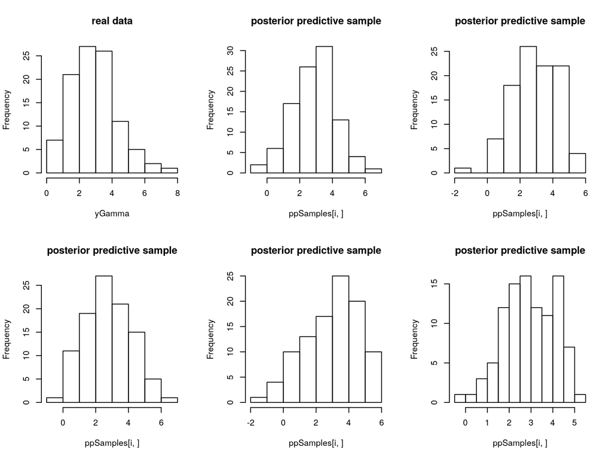

```r
par(mfrow = c(2, 3))
hist(yGamma, main = 'real data')
sub <- seq(1, 100, length = 5)
for(i in sub)
      hist(ppSamples[i, ], main = 'posterior predictive sample')
```

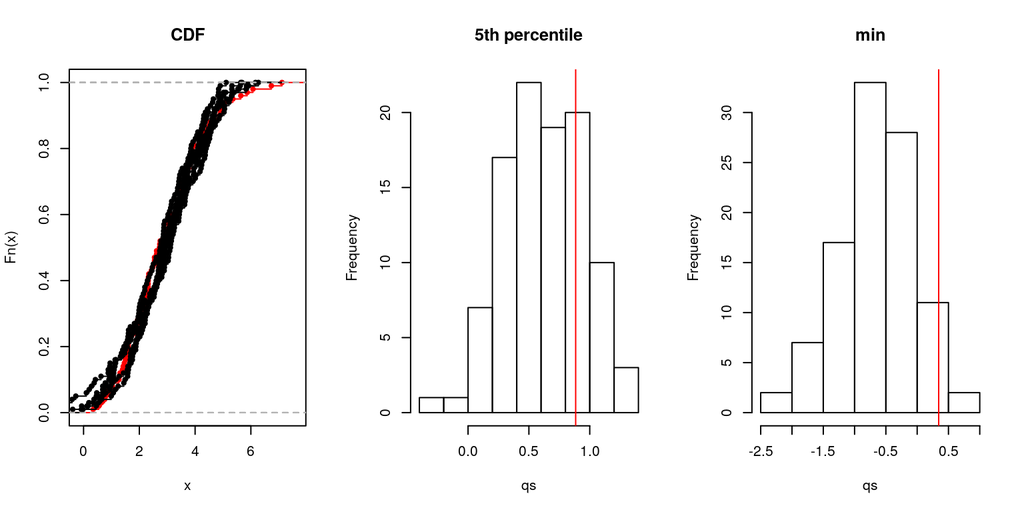

```r
par(mfrow = c(1,3))
plot(ecdf(yGamma), col = 'red', main = 'CDF')
for(i in sub)
      lines(ecdf(ppSamples[i, ]))


## Compare 5th percentiles
qs <- apply(ppSamples, 1, quantile, .05)
hist(qs, main = '5th percentile')
abline(v = quantile(yGamma, .05), col = 'red')

## Compare minima
qs <- apply(ppSamples, 1, min)
hist(qs, main = 'min')
abline(v = min(yGamma), col = 'red')
```

So it would be a bit hard to say based on this whether the model is appropriate or not, unless we had substantive reasons to know that the observations had to be non-negative.

The approach above could be slow, even with a compiled model, because the loop is carried out in R. We could instead do all the work in a compiled nimbleFunction.

# Posterior predictive sampling: writing a nimbleFunction

Let’s set up a nimbleFunction. In the setup code, we’ll manipulate the nodes and variables, similarly to the code we just discussed. In the run code, we’ll loop through the samples and simulate, also similarly.

Remember that all querying of the model structure needs to happen in the setup code.

```r
ppSampler <- nimbleFunction(
          setup = function(model, mcmc) {
                dataNodes <- model$getNodeNames(dataOnly = TRUE)
                parentNodes <- model$getParents(dataNodes, stochOnly = TRUE)
                cat("Stochastic parents of data are: ", paste(parentNodes, sep = ','), ".\n")
                simNodes <- model$getDependencies(parentNodes, self = FALSE)
                vars <- mcmc$mvSamples$getVarNames()  # need ordering of variables in mvSamples / samples matrix
                cat("Using posterior samples of: ", paste(vars, sep = ','), ".\n")
                nData <- length(model$expandNodeNames(dataNodes, returnScalarComponents = TRUE))
          },
          run = function(samples = double(2)) {
              niter <- dim(samples)[1]
              ppSamples <- matrix(nrow = niter, ncol = nData)
              for(i in 1:niter) {
                    values(model, vars) <<- samples[i, ]
                    model$simulate(simNodes, includeData = TRUE)
                    ppSamples[i, ] <- values(model, dataNodes)
              }
              return(ppSamples)
              returnType(double(2))
          })
```

# Posterior predictive sampling: using the nimbleFunction

```r
colnames(samples)
```

```
## [1] "mu"    "sigma"
```

```r
ppSampler_basic <- ppSampler(model_basic, mcmc_basic)
```

```
## Stochastic parents of data are:  mu sigma .
## Using posterior samples of:  mu sigma .
```

```r
cppSampler_basic <- compileNimble(ppSampler_basic, project = model_basic)
```

```
## compiling... this may take a minute. Use 'showCompilerOutput = TRUE' to see C++ compilation details.
```

```
## compilation finished.
```

```r
set.seed(1)
system.time(ppSamples_via_nf <- cppSampler_basic$run(samples))
```

```
##    user  system elapsed
##   0.001   0.000   0.001
```

```r
identical(ppSamples, ppSamples_via_nf)
```

```
## [1] TRUE
```

So we get exactly the same results (note the use of `set.seed`) but faster.

Here the speed doesn’t really matter but for more samples and larger models it often will, even after accounting for the time spent to compile the nimbleFunction.

# Post hoc posterior processing: example #2

Suppose we have a model where we can marginalize over latent variables, such as the two-component normal mixture from module 5.

What if we want inference on the latent variables?

# Post hoc posterior processing: Old Faithful mixture model

First let’s set up the (marginalized) mixture model and apply it to the `faithful` dataset.

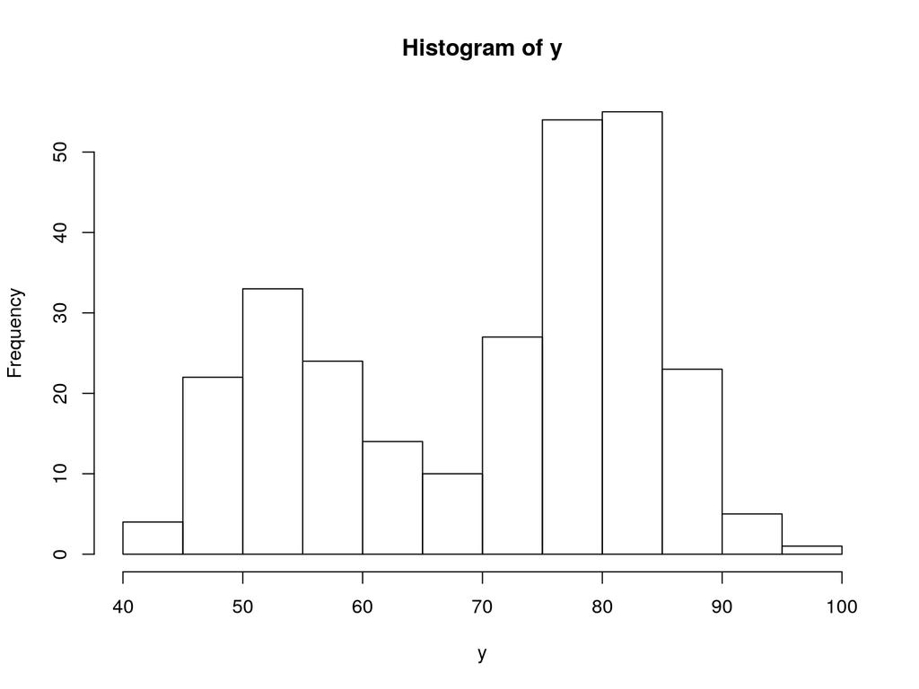

```r
dnormmix2 <- nimbleFunction(
  run = function(x = double(), prob = double(),
                 mean = double(1), sd = double(1),
                 log = logical(0, default = 0)) {
    returnType(double(0))
    dens <- prob*dnorm(x, mean[1], sd[1]) + (1-prob)*dnorm(x, mean[2], sd[2])
    if(log)
      return(log(dens)) else return(dens)
  })


code_marg <- nimbleCode({
     for(i in 1:n)
           y[i] ~ dnormmix2(p, mu[1:2], sigma[1:2])
     p ~ dunif(0, 1)
     for(j in 1:2) {
           mu[j] ~ dnorm(0, sd = 100)
           sigma[j] ~ dunif(0, 100)
     }
})

n <- nrow(faithful)
y <- faithful$waiting

hist(y)
```

```r
model_marg <- nimbleModel(code_marg, data = list(y = y), constants = list(n = n),
                           inits = list(p = 0.5, mu = mean(y) + c(-1,1)*sd(y), sigma = rep(sd(y)/2, 2)))
```

```
## defining model...
```

[output not shown]

```
## building model...
```

```
## setting data and initial values...
```

```
## running calculate on model (any error reports that follow may simply reflect missing values in model variables) ...
## checking model sizes and dimensions...
## model building finished.
```

```r
mcmc_marg <- buildMCMC(model_marg)
```

```
## ===== Monitors =====
## thin = 1: p, mu, sigma
## ===== Samplers =====
## RW sampler (5)
##   - p
##   - mu[]  (2 elements)
##   - sigma[]  (2 elements)
```

```r
cModel_marg <- compileNimble(model_marg)
```

```
## compiling... this may take a minute. Use 'showCompilerOutput = TRUE' to see C++ compilation details.
## compilation finished.
```

```r
cmcmc_marg <- compileNimble(mcmc_marg, project = model_marg)
```

```
## compiling... this may take a minute. Use 'showCompilerOutput = TRUE' to see C++ compilation details.
## compilation finished.
```

```r
set.seed(1)
system.time(paramSamples <- runMCMC(cmcmc_marg, niter = 5000, nburnin = 1000))  # 1.1 sec.
```

```
## running chain 1...
```

```
## |-------------|-------------|-------------|-------------|
## |-------------------------------------------------------|
```

```
##    user  system elapsed
##   1.025   0.000   1.026
```

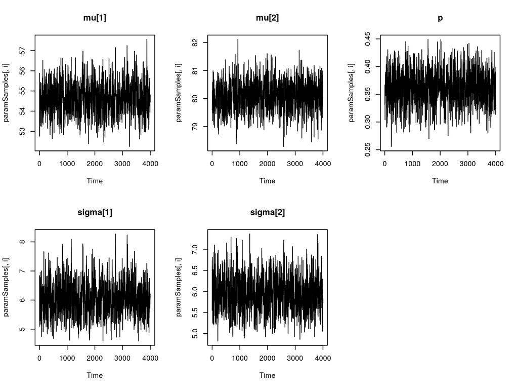

```r
nm <- colnames(paramSamples)
par(mfrow = c(2, 3))
for(i in 1:ncol(paramSamples))
      ts.plot(paramSamples[ , i], main = nm[i])
```

# Post hoc posterior processing: Old Faithful full model

Let’s see the version of the model that “breaks the mixture” and introduces latent variables giving the component membership of each observation.

```r
code_full <- nimbleCode({
     for(i in 1:n) {
           xi[i] ~ dbern(p)
           y[i] ~ dnorm(mu[xi[i]+1], sd = sigma[xi[i]+1])
     }
     p ~ dunif(0, 1)
     for(j in 1:2) {
           mu[j] ~ dnorm(0, sd = 100)
           sigma[j] ~ dunif(0, 100)
     }
})

n <- nrow(faithful)
y <- faithful$waiting
model_full <- nimbleModel(code_full, data = list(y = y), constants = list(n = n),
                           inits = list(p = 0.5, mu = mean(y) + c(-1,1)*sd(y), sigma = rep(sd(y)/2, 2),
                           xi = sample(0:1, n, replace = TRUE)))
```

```
## defining model...
```

```
## building model...
```

```
## setting data and initial values...
```

```
## running calculate on model (any error reports that follow may simply reflect missing values in model variables) ...
## checking model sizes and dimensions...
## model building finished.
```

```r
mcmc_full <- buildMCMC(model_full, monitors = model_full$getNodeNames(stochOnly = TRUE, includeData = FALSE))
```

```
## ===== Monitors =====
## thin = 1: p, mu, sigma, xi
## ===== Samplers =====
## RW sampler (3)
##   - p
##   - sigma[]  (2 elements)
## conjugate sampler (2)
##   - mu[]  (2 elements)
## binary sampler (272)
##   - xi[]  (272 elements)
```

```r
cModel_full <- compileNimble(model_full)
```

```
## compiling... this may take a minute. Use 'showCompilerOutput = TRUE' to see C++ compilation details.
## compilation finished.
```

```r
cmcmc_full <- compileNimble(mcmc_full, project = model_full)
```

```
## compiling... this may take a minute. Use 'showCompilerOutput = TRUE' to see C++ compilation details.
## compilation finished.
```

```r
set.seed(1)
system.time(paramSamples2 <- runMCMC(cmcmc_full, niter = 5000, nburnin = 1000))  # 1.3 sec
```

```
## running chain 1...
```

```
## |-------------|-------------|-------------|-------------|
## |-------------------------------------------------------|
```

```
##    user  system elapsed
##   1.124   0.012   1.136
```

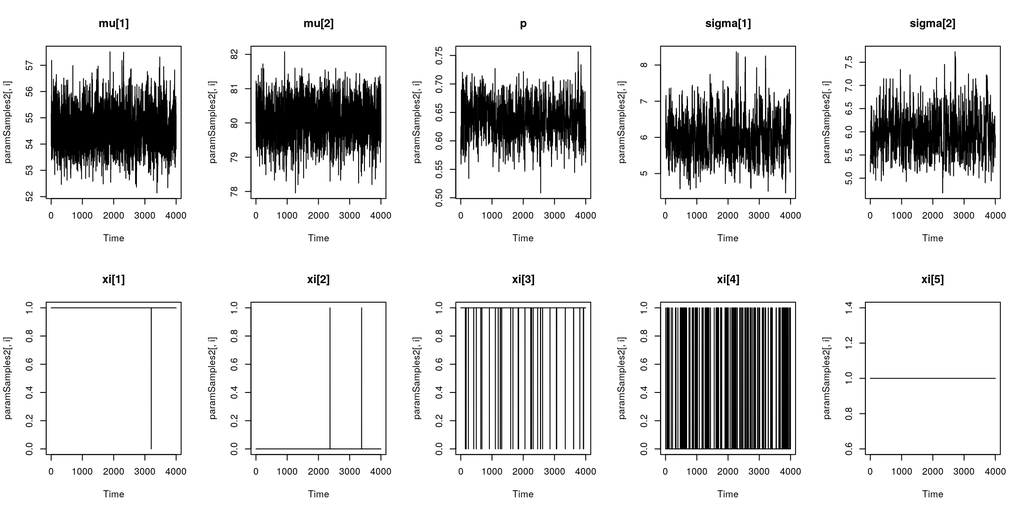

```r
nm <- colnames(paramSamples2)
par(mfrow = c(2, 5))
for(i in 1:10)
      ts.plot(paramSamples2[ , i], main = nm[i])
```

```r
## ESS comparison - not a clear winner, plus we should adjust for run-time...
print(c("marginalized", "full"))
```

```
## [1] "marginalized" "full"
```

```r
for(param in c('mu[1]','mu[2]','sigma[1]','sigma[2]', 'p'))
          print(c(effectiveSize(paramSamples[ , param]), effectiveSize(paramSamples2[ , param])))
```

```
##      var1      var1
##  495.4518 1004.2671
##      var1      var1
##  605.3181 1064.2723
##     var1     var1
## 512.1633 426.3572
##     var1     var1
## 552.1672 338.6910
##     var1     var1
## 789.5594 454.0574
```

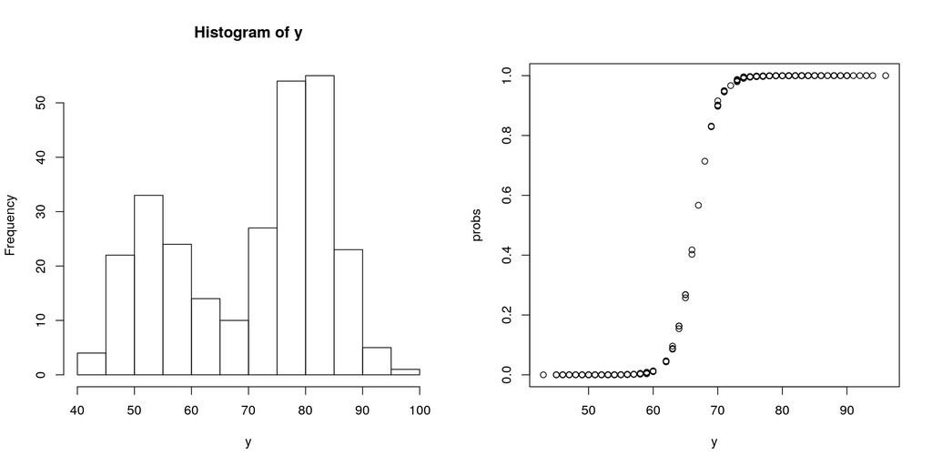

```r
wh <- grep('xi', nm)
probs <- apply(paramSamples2[ , wh], 2, function(x) mean(x == 1))

par(mfrow = c(1, 2))
hist(y)
plot(y, probs)
```

# Sampling latent variables using a nimbleFunction

Let’s brainstorm what we need to do to sample the `xi` variables if we have the posterior samples from the marginalized model.

Hint: can we use the samples from the marginalized model in the context of the full model?

```r
latentSampler <- nimbleFunction(
            setup = function(model, target, ???) {

            },
            run = function(???) {

            })
```

# Sampling latent variables using a nimbleFunction (2)

Here we:

- setup code:
  - setup a partial MCMC on the latent nodes
  - setup a modelValues for the latent node samples
- run code:
  - iterate through the posterior samples
  - put them in the model
  - run a 1-iteration MCMC for each sample (this is legit because of conjugacy)
  - save the sampled values into the new modelValues

```r
latentSampler <- nimbleFunction(
            setup = function(fullModel, sampledVars, target) {
                  ## target contains the nodes that have been integrated over that we want to sample from
                  targetNodes <- fullModel$expandNodeNames(target)

                  ## setup MCMC only for integrated-over nodes
                  conf <- configureMCMC(fullModel, nodes = targetNodes, monitors = targetNodes)

                  ## check everything is conjugate
                  samplers <- sapply(conf$getSamplers(),
                     function(x) x$name)
                  if(length(samplers) != length(grep("conjugate", samplers)) +
                                         length(grep("categorical", samplers)) +
                                         length(grep("binary", samplers)))
                     stop("Not all samplers are conjugate.")

                  ## note: haven't thought through if that is ok for multiple levels of marginalization...

                  ## In our marginalized model, we monitor all stochastic non-data nodes so should have everything we need stored.
                  ## For a general solution we would probably want to check that we have the nodes we need to do the sampling.

                  ## create MCMC object and modelValues for full model
                  mcmc <- buildMCMC(conf)
                  mvSamplesConf  <- conf$getMvSamplesConf(1)  ## modelValues 'configuration' ('1' is the first primary set of samples)
                  mvSamplesLatent <- modelValues(mvSamplesConf, m = 1)  ## default storage (m=1 row) for new samples
            },
            run = function(paramSamples = double(2)) {
                  ## dynamically determine how many samples we will get
                  ## ('paramSamples' might have been updated since setup code was run)
                  nIts <- dim(paramSamples)[1]
                  resize(mvSamplesLatent, nIts)

                  ## sample integrated-over nodes once per thinned iteration of original MCMC
                  for(i in 1:nIts) {
                      values(fullModel, sampledVars) <<- paramSamples[i, ]
                      fullModel$calculate()  # samplers assumes initial logProb, deterministic states are up-to-date
                      mcmc$run(1, reset = FALSE, progressBar = FALSE)
                      copy(fullModel, mvSamplesLatent, nodes = targetNodes, row = i)
                  }
            })
```

# Using the nimbleFunction

```r
## check ordering to be sure:
cmcmc_marg$mvSamples$getVarNames()
```

```
## [1] "mu"    "p"     "sigma"
```

```r
colnames(paramSamples)
```

```
## [1] "mu[1]"    "mu[2]"    "p"        "sigma[1]" "sigma[2]"
```

```r
latentSampler_full <- latentSampler(model_full, cmcmc_marg$mvSamples$getVarNames(), 'xi')
```

```
## ===== Monitors =====
## thin = 1: xi
## ===== Samplers =====
## binary sampler (272)
##   - xi[]  (272 elements)
```

```r
cLatentSampler_full <- compileNimble(latentSampler_full, project = model_full, resetFunctions = TRUE)
```

```
## compiling... this may take a minute. Use 'showCompilerOutput = TRUE' to see C++ compilation details.
```

```
## compilation finished.
```

```r
## Not necessary for correct sampling, just controls initial state solely for comparison with next approach.
cModel_full$xi <- rep(0, length(cModel_full$xi))

set.seed(1)
system.time({
cLatentSampler_full$run(paramSamples)
})
```

```
##    user  system elapsed
##   0.956   0.000   0.956
```

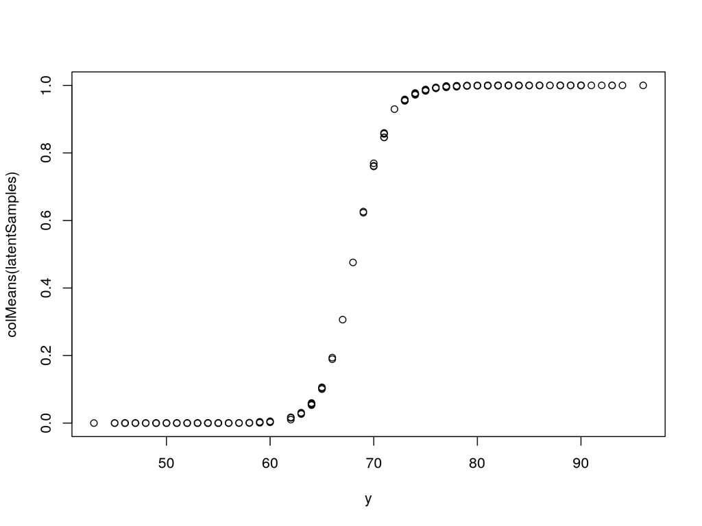

```r
latentSamples <- as.matrix(cLatentSampler_full$mvSamplesLatent)

par(mfrow = c(1, 1))
plot(y, colMeans(latentSamples))
```

# Using the compiled MCMC `mvSamples`

Here’s a slick way to make use of the samples stored in the original marginal MCMC. We pass the `mvSamples` from that MCMC in as a latent sampler setup argument. `nimble` figures out how to compile everything together and uses the samples stored in that original MCMC.

```r
latentSampler2 <- nimbleFunction(
            setup = function(fullModel, mvSamplesParam, target) {
                  ## target contains the nodes that have been integrated over that we want to sample from
                  targetNodes <- fullModel$expandNodeNames(target)

                  ## setup MCMC only for integrated-over nodes
                  conf <- configureMCMC(fullModel, nodes = targetNodes, monitors = targetNodes)

                  ## check everything is conjugate
                  samplers <- sapply(conf$getSamplers(),
                     function(x) x$name)
                  if(length(samplers) != length(grep("conjugate", samplers)) +
                                         length(grep("categorical", samplers)) +
                                         length(grep("binary", samplers)))
                     stop("Not all samplers are conjugate.")

                  ## note: haven't thought through if that is ok for multiple levels of marginalization...

                  ## In our marginalized model, we monitor all stochastic non-data nodes so should have everything we need stored.
                  ## For a general solution we would probably want to check that we have the nodes we need to do the sampling.

                  ## create MCMC object and modelValues for full model
                  mcmc <- buildMCMC(conf)
                  mvSamplesConf  <- conf$getMvSamplesConf(1)  ## modelValues 'configuration' ('1' is the first primary set of samples)
                  mvSamplesLatent <- modelValues(mvSamplesConf, m = 1)  ## default storage (m=1 row) for new samples
                  sampledVars <- mvSamplesParam$getVarNames()
            },
            run = function(nIts = double(0)) {
                 resize(mvSamplesLatent, nIts)

                 ## sample integrated-over nodes once per thinned iteration of original MCMC
                 for(i in 1:nIts) {
                      nimCopy(mvSamplesParam, fullModel, row = i, sampledVars)
                      fullModel$calculate()  # samplers assume initial logProb, deterministic states are up-to-date
                      # so we need an up-to-date model before doing the single MCMC step
                      mcmc$run(1, reset = FALSE, progressBar = FALSE)
                      nimCopy(fullModel, mvSamplesLatent, nodes = targetNodes, row = i)
                 }
            })


latentSampler2_full <- latentSampler2(model_full, mcmc_marg$mvSamples, 'xi')
```

```
## ===== Monitors =====
## thin = 1: xi
## ===== Samplers =====
## binary sampler (272)
##   - xi[]  (272 elements)
```

```r
cLatentSampler2_full <- compileNimble(latentSampler2_full, project = model_full, resetFunctions = TRUE)
```

```
## compiling... this may take a minute. Use 'showCompilerOutput = TRUE' to see C++ compilation details.
```

```
## compilation finished.
```

```r
cModel_full$xi <- rep(0, length(cModel_full$xi))   # control initial state

set.seed(1)
system.time({
cLatentSampler2_full$run(nrow(paramSamples))
})
```

```
##    user  system elapsed
##   0.820   0.000   0.821
```

```r
latentSamples2 <- as.matrix(cLatentSampler2_full$mvSamplesLatent)

identical(latentSamples, latentSamples2)  # great!
```

```
## [1] TRUE
```

# Calling out to R in a nimbleFunction

Suppose we want to do some calculation that is hard or impossible to implement in the NIMBLE DSL, i.e., the functionality that is available in run code that NIMBLE can compile to C++. We can actually call arbitrary R code from within run code.

Here we’ll use an existing R function. Other options include:

- writing our own R function from scratch
- writing a simple wrapper R function that calls an existing R function but rearranges arguments for convenience

```r
Rquantile <- nimbleRcall(function(x = double(1), probs = double(1)) {},
          returnType = double(1), Rfun = 'quantile')

ppSamplerQ <- nimbleFunction(
          setup = function(model, mcmc, dataNodes) {
                dataNodes <- model$getNodeNames(dataOnly = TRUE)
                parentNodes <- model$getParents(dataNodes, stochOnly = TRUE)
                simNodes <- model$getDependencies(parentNodes, self = FALSE)
                vars <- mcmc$mvSamples$getVarNames()  # need ordering of variables in mvSamples / samples matrix
                nData <- length(model$expandNodeNames(dataNodes, returnScalarComponents = TRUE))
          },
          run = function(samples = double(2), probs = double(1)) {
              niter <- dim(samples)[1]
              ppSamples <- matrix(nrow = niter, ncol = length(probs))
              for(i in 1:niter) {
                    values(model, vars) <<- samples[i, ]
                    model$simulate(simNodes, includeData = TRUE)
                    ppSamples[i, ] <- Rquantile(values(model, dataNodes), probs)
              }
              return(ppSamples)
              returnType(double(2))
          })

ppSamplerQ_example <- ppSamplerQ(model_basic, mcmc_basic)
ppSamplerQ_example_comp <- compileNimble(ppSamplerQ_example, project = model_basic)
```

```
## compiling... this may take a minute. Use 'showCompilerOutput = TRUE' to see C++ compilation details.
```

```
## compilation finished.
```

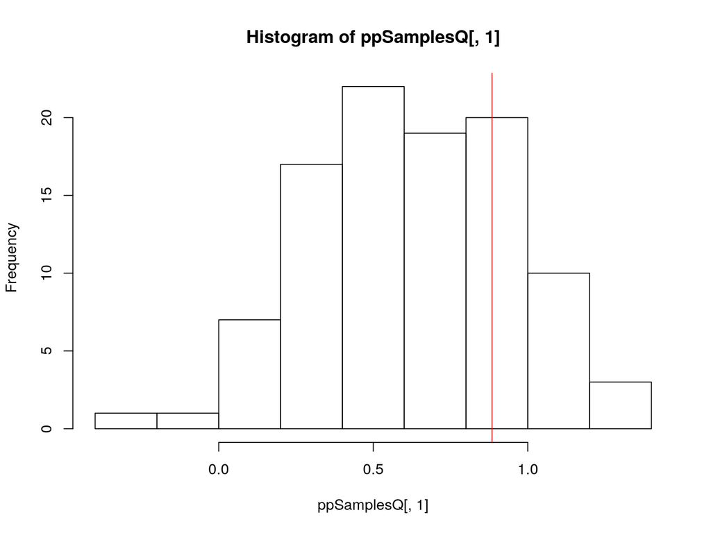

```r
set.seed(1)
## This will work with one or more quantiles. Here we get a 1-column matrix output.
ppSamplesQ <- ppSamplerQ_example_comp$run(samples, .05)

hist(ppSamplesQ[ , 1])
abline(v = quantile(yGamma, .05), col = 'red')
```

# Calling external C/C++ code

Let’s repeat the external call but using C++ code. In this case, there’s not much advantage to having our own C++ code and the R `quantile` function is well-vetted, so the main point is illustrating how to call out to C++.

Note: `nimble` auto-generates C++ code from run code. Here we are writing our own C++ code and calling that from a nimbleFunction.

```r
Cquantile <- nimbleExternalCall(
     prototype = function(x = double(1), probs = double(1),
         out = double(1), n = integer(), k = integer()){},
     returnType = void(),
     Cfun =  'quantile',
     headerFile = file.path(getwd(), 'quantile.h'),
     oFile = file.path(getwd(), 'quantile.o'))

system('g++ quantile.cpp -c -o quantile.o')

ppSamplerQ2 <- nimbleFunction(
          setup = function(model, mcmc) {
                dataNodes <- model$getNodeNames(dataOnly = TRUE)
                parentNodes <- model$getParents(dataNodes, stochOnly = TRUE)
                simNodes <- model$getDependencies(parentNodes, self = FALSE)
                vars <- mcmc$mvSamples$getVarNames()  # need ordering of variables in mvSamples / samples matrix
                nData <- length(model$expandNodeNames(dataNodes, returnScalarComponents = TRUE))
          },
          run = function(samples = double(2), probs = double(1)) {
              niter <- dim(samples)[1]
              k <- length(probs)
              ppSamples <- matrix(nrow = niter, ncol = k)
              for(i in 1:niter) {
                    values(model, vars) <<- samples[i, ]
                    model$simulate(simNodes, includeData = TRUE)
                    Cquantile(values(model, dataNodes), probs, ppSamples[i, ], nData, k)
              }
              return(ppSamples)
              returnType(double(2))
          })

ppSamplerQ2_example <- ppSamplerQ2(model_basic, mcmc_basic)
ppSamplerQ2_example_comp <- compileNimble(ppSamplerQ2_example, project = model_basic)
```

```
## compiling... this may take a minute. Use 'showCompilerOutput = TRUE' to see C++ compilation details.
```

```
## compilation finished.
```

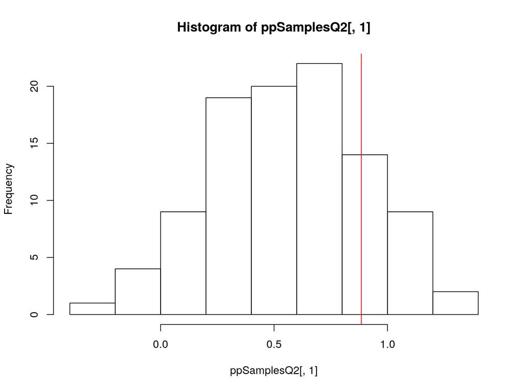

```r
set.seed(1)
## This will work with one or more quantiles. Here we get a 1-column matrix output.
ppSamplesQ2 <- ppSamplerQ2_example_comp$run(samples, .05)

hist(ppSamplesQ2[ , 1])
abline(v = quantile(yGamma, .05), col = 'red')
```

Comments:

- We allocate space for the result in the nimbleFunction. Don’t allocate memory in the C/C++ code as `nimbleExternalCall` and return the allocated object, as NIMBLE is not set up to deal with freeing memory.
  - Allocating memory and de-allocating it within the C/C++ code is fine.
- The values are not exactly what we got from the R quantile function. We’d want to compare exactly how empirical quantiles are defined by the R and C++ code.